# Analyze Flight Data: Visualization Project

#### Sarah Griggs

- Introduction
- Part I - Initial Data Investigation & Cleaning
- Part II - Explanatory Analysis

### Introduction

This analysis will look at flight data from a period of 5 years, 2004 through 2008, to determine if there are patterns in delays change over time intervals.  
This analysis is particularily interested in questions revolving around flight delays. Questions Explored are as follows:

1. How are flight delays associated with years?  
   1a. Do some years have more delays than others?  
   1b. Does total delays as a percentage of total flights align with total delays per year?  
   1c. Do certain types of delays contribute more to the yearly delay total than others?
2. How are filght delays associated with day of week?
3. How are flight delays associated with month of year?
4. How are flight delays in total distributed among carriers?  
   4a. Do total delays per flight carrier change as years progress?

### Part I - Initial Data Investigation & Cleaning

Cleaning and an intital exploration of the data was preformed. The data was read in as 5 separtate data frames and then appeneded into a master. A datetime variable was created from the 3 columns, year, month, and day. This date time variable allows for easier reads of correlations. An additional boolean delay variable was created in order to indicate ifa delay was present at all. Last, individual delay booleans were created for each type of delay so that we could analyze these occurances as aggregates instead of minute amounts.

### Part II - Exploratory Analysis

## How are flight delays associated with years?

```
Text(0.5,1,'Percentage of Total Flights that Are Delays by Year')
```

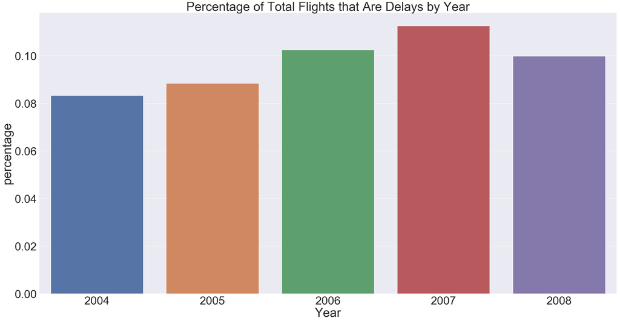

```python
sb.set(font_scale=4)
sb.barplot(x="Year", y="percentage", data = merge13, saturation=0.8).set_title("Percentage of Total Flights that Are Delays by Year")
```

How are flight associated with year? Here we can see that delays as a percentage of total flights increase as years increase from 2004 to 2007, where 2007 is the local maximum. In 2008 we start to see this percentage decline.

```python
#Here I want to confirm that 2007 was the peak of delays in total
plotdf9 = df.groupby(['Year','Delay']).size().reset_index(name='counts')
plotdf9 = plotdf9[plotdf9['Delay'] == 1]
plotdf10 = df.groupby(['Year']).size().reset_index(name='totalflights')
merge13 = pd.merge(plotdf9, plotdf10, left_on = 'Year', right_on = 'Year')

merge13['percentage'] = merge13['counts']/merge13['totalflights']
merge13
#by Percent we see that 2007 was the peak
```

|  | Year | Delay | counts | totalflights | percentage |
| --- | --- | --- | --- | --- | --- |
| 0 | 2004 | 1 | 593926 | 7129270 | 0.083308 |
| 1 | 2005 | 1 | 630944 | 7140596 | 0.088360 |
| 2 | 2006 | 1 | 731324 | 7141922 | 0.102399 |
| 3 | 2007 | 1 | 838599 | 7453215 | 0.112515 |
| 4 | 2008 | 1 | 699418 | 7009728 | 0.099778 |

Here we can see that total delays does, in fact, algin with the largest percentage of delays.

```
True
```

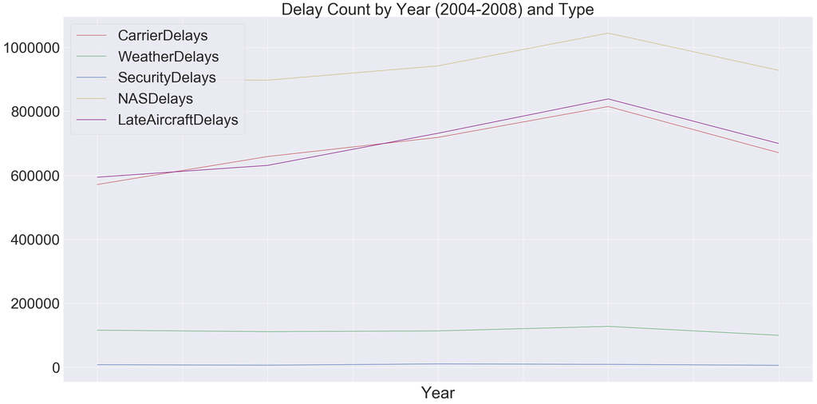

```python
#Here we see that NAS delays are the most prevalent along with Late Aircraft and Carrier. Security is the least prevalent.
ax1 = merge4.plot(x='Year', y='CarrierDelays', color='r', title = 'Delay Count by Year (2004-2008) and Type')
ax2 = merge4.plot(x='Year', y='WeatherDelays', color='g', ax=ax1)
ax3 = merge4.plot( x='Year', y='SecurityDelays', color='b', ax=ax1)
ax4 = merge4.plot( x='Year', y='NASDelays', color='y', ax=ax1)
ax5 = merge4.plot( x='Year', y='LateAircraftDelays', color='purple', ax=ax1)
print(ax1 == ax2 == ax3 == ax4 == ax5)
```

Here we can see a different visualization showing delay count over time. We see that NAS delays are the most common. This makes sense because NAS delays generalize many common delays that aren't serious. We also see the peak in 2007 as we saw previously.

## How are flight delays associated with day of week?

```
Text(0.5,1,'Percentage of Flights that are Delayed by Day of Week')
```

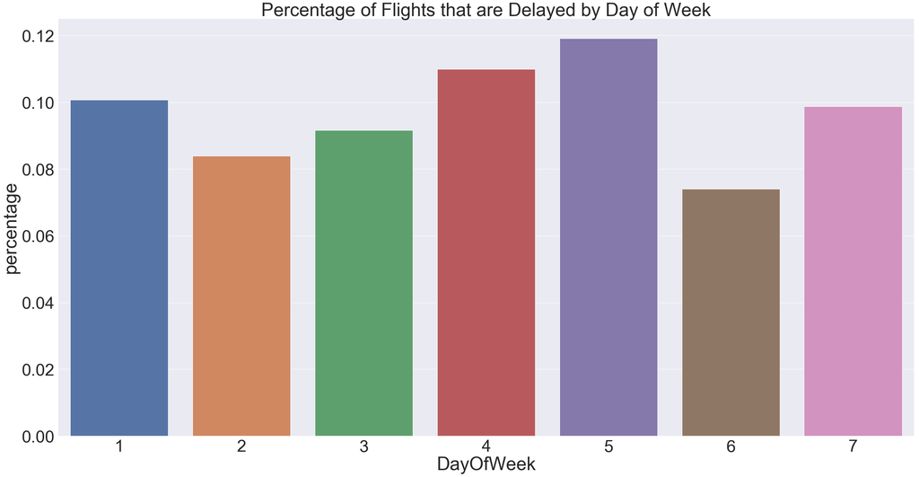

```python
#This graph explores the relationship between overall delays and day of week
sb.set(font_scale=4)
sb.barplot(x="DayOfWeek", y="percentage", data = merge6, saturation=0.8).set_title("Percentage of Flights that are Delayed by Day of Week")
```

We can see that day of week has a strong association with total delays. We see the most delays on day 5, which is Friday.

```
Text(0.5,1,'Percentage of Total Flights that are Delays by Month')
```

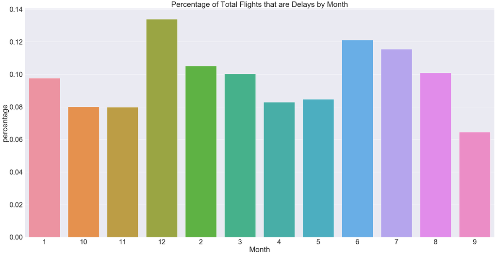

```python
sb.set(rc={'figure.figsize':(40,20)})
sb.set(font_scale=3)
sb.barplot(x="Month", y="percentage", data = merge14, saturation=0.8).set_title("Percentage of Total Flights that are Delays by Month")
```

Here we can see that months with more extreme weather as well as holidays have more flight delays per flights. There is certainly a seasonal aspect to this data that could be further explored to determine exact significance of month and even day within month.

## How are flight delays in total distributed among carriers?

```
Text(0.5,1,'Percentage of Total Flights that are Delays, by Carrier, by Year')
```

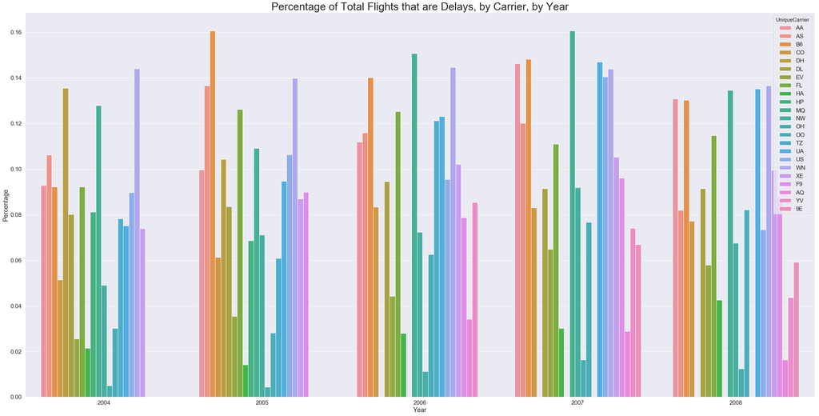

```python
sb.set(rc={'figure.figsize':(40,20)})
sb.set(font_scale=1.5)
sb.barplot(x="Year", y="Percentage", hue='UniqueCarrier', data = carrierDelayFull, saturation=0.8).set_title("Percentage of Total Flights that are Delays, by Carrier, by Year", fontsize=30)
```